# Do hot naked selfies get the most likes on Instagram?

## A case study

My favorite instagrammer once said something along the lines of "I have thousands of professional modeling photos, but all you guys want to see is mirror selfies of me in my underwear."

Is this true? Would the average viewer prefer a candid lingerie photo over a glitzy shot on set with hair, makeup, wardrobe, etc? I decided to find out.

### Imports

```python
import numpy as np
import pandas as pd
from scipy.stats import f_oneway, linregress, kruskal
import matplotlib.pyplot as plt
import matplotlib.image as mpimg
import urllib.request
from InstagramAPI import InstagramAPI
```

### Instagram API

Shout out to [LevPasha](https://github.com/LevPasha/Instagram-API-python) on GitHub for writing these APIs. He did all the hard work.

```python
api = InstagramAPI('username', 'password')
```

Login to my account.

```python
api.login()
```

```
Request return 429 error!
{'message': 'Please wait a few minutes before you try again.', 'status': 'fail'}
Request return 405 error!
{'message': '', 'status': 'fail'}
Login success!
```

```
True
```

### Instagrammer Selection

Obviously to do this in real depth would require pulling data from at least hundreds of users. That way you can control for differences between a given user's following and with more data points the trends found tend to be more extrapalatable. For example, different cultures have different beauty standards. People will follow different versions of what they consider attractive on Instagram and this will ripple over into which photos get the most likes and comments. Thus only looking at a single user won't necessarily provide insight into greater trends. However, I don't have that kind of free time.

My crush du jour is [Teddy Quinlivan](https://www.instagram.com/teddy_quinlivan/), so we'll be using her account as the data set. She has over 1000 photos ranging from walking the Louis Vuitton runway to pulling lewks at China Chalet to random art finds. There's a lot of hot content on her account, but there's also a plethora of content that might disinterest the typical male [@emrata](https://www.instagram.com/emrata/) follower. Hopefully this will give us enough variation to see if the hot selfies really do get all the likes.

Using the API we'll search for her account by handle and find her account number.

```python
api.searchUsername('teddy_quinlivan')
for i in list(api.LastJson['user'])[0:10]:
    print(f"{i} : {api.LastJson['user'][i]}")
```

```
pk : 1904001441
username : teddy_quinlivan
full_name : Theodora Quinlivan
is_private : False
profile_pic_url : https://scontent-lga3-1.cdninstagram.com/v/t51.2885-19/s150x150/90901580_251296382705931_6927693209480986624_n.jpg?_nc_ht=scontent-lga3-1.cdninstagram.com&_nc_ohc=C7ppL2OM7OgAX-DsGHK&oh=4b5529b0b04b570b63ad07c9093d7654&oe=5ED693B3
profile_pic_id : 2273760107720714097_1904001441
is_verified : True
has_anonymous_profile_picture : False
media_count : 1194
geo_media_count : 0
```

### Scraping the data

Now that we've found her account number we can get her entire feed and all meta data with a single command.

```python
user_data = api.getTotalUserFeed('1904001441')
```

From the raw data I'd like to collect 5 features: the timestamp, number of likes, number of comments, the caption, and location.

The API grabs the data with the most recent post as 0, so we'll reverse iterate through it so we can save the photos numbered from 0 being the first photo she ever posted to n being the most recent. I've placed all the feature grabbing lines in try/excepts because I found some photos had comments disabled or no location data as the feature was not part of the original app. For posts without this data 0/nulls were inserted into the data set.

I made a TQ_Data folder on my desktop which will hold all of her photos numbered by post and a csv containing the metadata. The index of the csv will match the photo number.

```python
columns = ['timestamp', 'likes', 'comments', 'caption', 'location']
ar = np.zeros((len(user_data), len(columns)))
df = pd.DataFrame(ar, columns=columns)
print(len(user_data))
for i in range(len(user_data) - 1, -1, -1): # loop backwards so first photo is 0 and most recent is n
    try:
        time = user_data[i]['taken_at']
    except:
        time = ''
    try:
        likes = user_data[i]['like_count']
    except:
        likes = 0
    try:
        comments = user_data[i]['comment_count'] # comments may be disabled
    except:
        comments = 0
    try:
        caption = user_data[i]['caption']['text']
    except:
        caption = ''
    try:
        location = user_data[i]['location']['name'] # location wasn't always a feature
    except:
        location = ''

    df.loc[len(user_data) - i - 1, :] = [time, likes, comments, caption, location]

    try:
        link = TQ_data[i]['image_versions2']['candidates'][0]['url']
        urllib.request.urlretrieve(link, f'~/Desktop/TQ_Data/TQ_{len(TQ_data) - i - 1}.jpg')
    except:
        try:
            link = TQ_data[i]['carousel_media'][1]['image_versions2']['candidates'][0]['url']
            urllib.request.urlretrieve(link, f'~/Desktop/TQ_Data/TQ_{len(TQ_data) - i - 1}.jpg')
        except:
            pass

df.to_csv('~/Desktop/TQ_Data/TQ_Data.csv')
```

```
1194
```

## Data Labeling

The funny thing about machine learning is that the intial steps are pretty human intensive. Before computers and data scientists can do anything with image data the data has to be labeled. Humans know cats versus dogs by sight, but a computer has to relate it to the 3 letter word c-a-t.

That means I went through over 1000 photo manually labeling features: rating, showing, taken_by.

Let's break this down because this is the most controversial/important part. Classifying images in the context of this study is subjective, so I made the decision to add a couple new features to help define each image. That being said, the labels used were predominantly a product of the model chosen. Given this account's content there was no need to create labels such as gym pic or booty pic as Teddy is neither a "fit-chick" nor bikini model. This once again reduces the likelihood that trends found are reflected in the greater model/influencer Instamgram community. At any rate, these are the features and associated labels defined and I already regret not including thirst trap.

**Rating**: a measure of attractiveness

- Casual: a photo of the user in a normal day-to-day context
- Glamour Shot: a photo that evidences prior setup (eg. a fashion show or something clearly not candid)
- Hot: a photo of the user clothed where it seems a more than usual effort was made to look attractive
- Not Self: a photo of anything other than the user (may include other people, objects, drawings, etc)
- Nude: a photo where the user is naked
- Scantily Clad: a photo where the user is wearing highly revealing clothing

**Showing**: a measure how much of the user's body is shown

- Body: a photo containing either the entirety or majority of the user's body
- Bust: a photo of the user from the bust up
- Head: a photo of the user's head
- null: photos not of the user are marked null

**Taken By**: tagging the photographer

- Amateur: a photo taken by any non-professional
- Professional: a photo taken by what appears to be a career photographer
- Self: a photo taken by the user - a selfie in the modern parlance
- null: photos not of the user are marked null

### Subjectivity

The choosing of these features and each one of their facets is a highly subjective matter. One could argue that just by the items chosen I have already skewed that data and introduced a bias. Probably. I acknowledge there are better ways to do this, for example conducting preliminary studies to see how other people categorize the images or having multiple people label the photos to control for personal preferences.

I'm doing this for fun, so doing all of that would have been a lot more than I bargained for. It just means that the results in this study are dependant on the labels used and the account chosen. Whether the conclusions in here map over to the rest of Instagram... who knows. Maybe another day I or another may take this up again and conduct it with more scientific rigor.

### Examples

Before going on, it might be helpful to see an example of each of the categories defined above. Examples of several label combinations are shown in the appendix. First let's make a function to easily plot images by their number.

```python
def plot_img(num):
    plt.figure(figsize=(5, 5))
    plt.axis('off')
    plt.imshow(mpimg.imread(f'/Users/XXI/Desktop/TQ_Data/TQ_{num}.jpg'));
```

If you're too lazy to scroll to the appendix to see some labeled photos, here's what she looks like:

[figure not shown]

```python
plot_img(865) # 865 956
```

## Analysis

### Data: import, clean, augment

We'll begin by reading in the data and taking a brief look to check that there's no glaring error.

```python
data = pd.read_csv('/Users/XXI/Desktop/TQ_Data/TQ_Data.csv', header=0, low_memory=False)
display(data.head(3))
```

|  | photo_num | timestamp | likes | comments | caption | location | rating | showing | taken_by |
| --- | --- | --- | --- | --- | --- | --- | --- | --- | --- |
| 0 | 1192 | 1588103199 | 4765 | 113 | A-K-R-I-S spring 2020 Campaign 💙 Thank you so ... | Paris, France | glamour shot | body | professional |
| 1 | 1191 | 1588003187 | 1102 | 9 | 👁 | Los Angeles, California | not self | NaN | NaN |
| 2 | 1190 | 1587754491 | 13576 | 291 | Good Sex, No Stress, One Boo, No Ex, Small Cir... | Los Angeles, California | scantily clad | body | self |

Looks good, so next we can replace the NaNs with null and check the unique values in our primary columns to make sure they're correct.

```python
data.fillna('null', inplace=True) # replace blanks with null
print(data['rating'].unique())
print(data['showing'].unique())
print(data['taken_by'].unique())
```

```
['glamour shot' 'not self' 'scantily clad' 'casual' 'hot' 'nude']
['body' 'null' 'bust' 'head']
['professional' 'null' 'self' 'amateur']
```

If we end up doing some time of post analysis to find the optimal day/hour to upload to the gram it'll be useful to deconstruct the timestamp. We'll break it down from unix time to date, year, day, and hour.

```python
data['datetime'] = pd.to_datetime(data['timestamp'], unit='s') # convert timestamp from unix time
data['date'] = data['datetime'].dt.date # I was planning to use timestamps to find the optimal time to post
data['year'] = data['datetime'].dt.year.astype(int) # that would've taken too much time
data['day'] = data['datetime'].dt.dayofweek.astype(int)
data['hour'] = data['datetime'].dt.strftime('%H').astype(int)
display(data.head(3))
```

|  | photo_num | timestamp | likes | comments | caption | location | rating | showing | taken_by | datetime | date | year | day | hour |
| --- | --- | --- | --- | --- | --- | --- | --- | --- | --- | --- | --- | --- | --- | --- |
| 0 | 1192 | 1588103199 | 4765 | 113 | A-K-R-I-S spring 2020 Campaign 💙 Thank you so ... | Paris, France | glamour shot | body | professional | 2020-04-28 19:46:39 | 2020-04-28 | 2020 | 1 | 19 |
| 1 | 1191 | 1588003187 | 1102 | 9 | 👁 | Los Angeles, California | not self | null | null | 2020-04-27 15:59:47 | 2020-04-27 | 2020 | 0 | 15 |
| 2 | 1190 | 1587754491 | 13576 | 291 | Good Sex, No Stress, One Boo, No Ex, Small Cir... | Los Angeles, California | scantily clad | body | self | 2020-04-24 18:54:51 | 2020-04-24 | 2020 | 4 | 18 |

### First look

The plot below shows likes and comments on photos over time. What's interesting to notice is the large spread in likes on the more recent photos. While some photos begin to amass over 10k likes regularly, others still fail to get over 2.5k. Not all photos necessarily got more likes as her following grew.

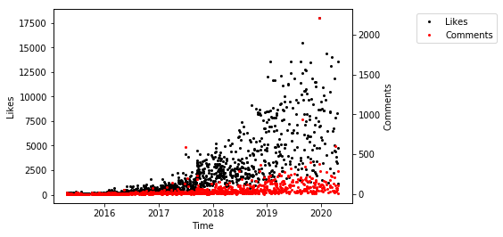

```python
fig, ax = plt.subplots()
plt1 = ax.plot_date(data['date'], data['likes'], color='k', markersize=2)
ax0 = ax.twinx()
plt2 = ax0.plot_date(data['date'], data['comments'], color='r', markersize=2)
ax.set_xlabel('Time')
ax.set_ylabel('Likes')
ax0.set_ylabel('Comments')
plts = plt1 + plt2
labels = ['Likes', 'Comments']
ax.legend(plts, labels, bbox_to_anchor=[1.5, 0, 0, 1]);
```

### Detrend

When someone joins Instagram they have 0 followers. The increase in likes over time is directly correlated to the number of followers she's gained over the years. Unfortunately, it's not possible get the number of followers in time, so we can't detrend it directly based on follower count. To truly compare likes in one photo to the next, especially over time we need to detrend the data another way. Let's first take the natural log of the likes and comments.

```python
data0 = data.copy()
data0['likes'] = np.log(data0['likes'] + 1)
data0['comments'] = np.log(data0['comments'] + 1)
```

In the plot below we'll see that the data is already a lot neater and a more evident trend appears. So let's go ahead and make a linear regression of the likes and comments.

```python
linreg_likes = linregress(data0['timestamp'], data0['likes'])
linreg_comments = linregress(data0['timestamp'], data0['comments'])
print(linreg_likes)
print(linreg_comments)
```

```
LinregressResult(slope=3.033517640182872e-08, intercept=-38.69763788807153, rvalue=0.913692480812176, pvalue=0.0, stderr=3.909767975785163e-10)
LinregressResult(slope=2.4329443186707576e-08, intercept=-33.667519565206305, rvalue=0.7765580821432169, pvalue=3.3540393430796435e-241, stderr=5.719714814442726e-10)
```

Plotting the data now with the linear regressions it seems there's a pretty good fit. Note that the streaking pattern in comments on the lower left is caused by photos receiving few comments early in her account history. If photos are only getting 1-10 comments the spread is quite small relative to photos getting 10-100 comments, hence why the comments scatter plot starts off streaked and then becomes more scattered.

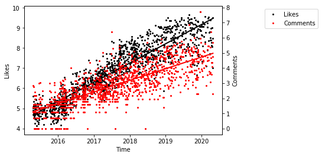

```python
fig, ax = plt.subplots()
plt1 = ax.plot_date(data0['date'], data0['likes'], color='k', markersize=2)
ax.plot_date(data0['date'], data0['timestamp']*linreg_likes[0] + linreg_likes[1], color='k', linestyle='-', linewidth=2, alpha=1, marker=None)
ax0 = ax.twinx()
plt2 = ax0.plot_date(data0['date'], data0['comments'], color='r', markersize=2)
ax0.plot_date(data0['date'], data0['timestamp']*linreg_comments[0] + linreg_comments[1], color='r', linestyle='-', linewidth=2, alpha=1, marker=None)
ax.set_xlabel('Time')
ax.set_ylabel('Likes')
ax0.set_ylabel('Comments')
plts = plt1 + plt2
labels = ['Likes', 'Comments']
ax.legend(plts, labels, bbox_to_anchor=[1.5, 0, 0, 1]);
```

Now let's subtract out the regression and normalize the values between 0 and 1. This will fully detrend the data a give an easy to use metric: normalized likes and comments.

```python
data0['likes'] -= data0['timestamp']*linreg_likes[0] + linreg_likes[1]
data0['comments'] -= data0['timestamp']*linreg_comments[0] + linreg_comments[1]

data0['likes'] = (data0['likes'] - min(data0['likes']))/(max(data0['likes']) - min(data0['likes']))
data0['comments'] = (data0['comments'] - min(data0['comments']))/(max(data0['comments']) - min(data0['comments']))
```

Finally we have a fully detrended and normalized data set. These values will make it possible to compare likes and comments over time from one image to another.

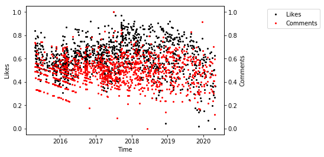

```python
fig, ax = plt.subplots()
plt1 = ax.plot_date(data0['date'], data0['likes'], color='k', markersize=2)
ax0 = ax.twinx()
plt2 = ax0.plot_date(data0['date'], data0['comments'], color='r', markersize=2)
ax.set_xlabel('Time')
ax.set_ylabel('Likes')
ax0.set_ylabel('Comments')
plts = plt1 + plt2
labels = ['Likes', 'Comments']
ax.legend(plts, labels, bbox_to_anchor=[1.5, 0, 0, 1]);
```

### So do hot naked selfies get the most likes?

Yes, but not really. For each of the three main features there are plots below of the number of photos for each label in the feature and the number of normalized likes per photo for the label. Photos rated as nude, of the bust, taken by the user receive the most likes as independant features . However, photos rated as glamour shots bring in 0.84 normalized likes for every normalized like a nude photo gets. Even casual photos get about the same amount. Photos labeled as not self are the real losers bringing in only 0.65 normalized likes per photo.

In the other categories we see a similar pattern among the labels. The spread between photos of the head, bust, and body isn't that large, but all three of those values differ a lot from the value for the label null. The same is true for the feature taken_by. All of this is to say that the biggest difference is between photos of the user versus photos not of the user. Hot photos do better than not hot photos, but as long as they're of the user the variance isn't that large.

```
nude photos get the most normalized likes per photo and not self get the least
bust photos get the most normalized likes per photo and null get the least
self photos get the most normalized likes per photo and null get the least
```

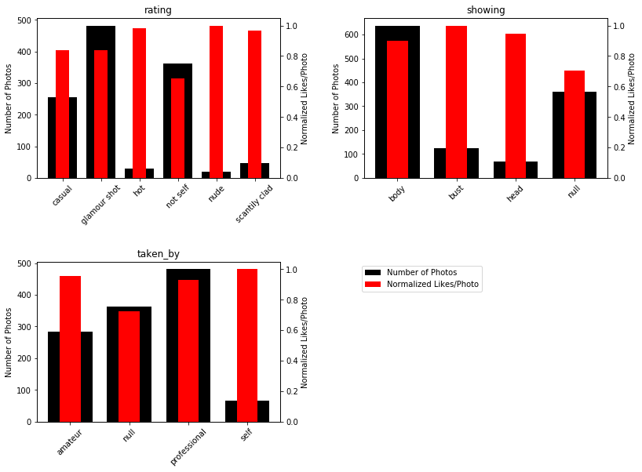

```python
features = ['rating', 'showing', 'taken_by']
def plot_bar_labels(df, features):
    fig, ax = plt.subplots(2, 2, figsize = (12, 9)) # make 4 subplots
    ax = ax.reshape(-1) # reshape to make easy to index
    for i in range(len(features)): # go through all features
        label = features[i]
        label_x = np.sort(df[label].unique())
        label_y = []
        label_likes = []
        cat_var = []
        for j in label_x: # go through all labels in each feature
            label_y.append(len(df.loc[df[label] == j])) # get number of photos with the given label
            label_likes.append(sum(df.loc[df[label] == j]['likes'])/label_y[-1]) # get number of likes/photo
        label_likes = np.array(label_likes)/max(label_likes) # normalize again to make plot max 1

        plt1 = ax[i].bar(label_x, label_y, width=0.75, color='k') # plot number of photos
        ax0 = ax[i].twinx()
        plt2 = ax0.bar(label_x, label_likes, width=0.35, color='r') # plot number of likes/photo
        ax[i].set_xticklabels(label_x, rotation=45)
        ax[i].set_ylabel('Number of Photos')
        ax0.set_ylabel('Normalized Likes/Photo')
        plts = [plt1, plt2]
        labels = ['Number of Photos', 'Normalized Likes/Photo']
        ax[i].set_title(label) # print most liked and least liked label
        print(f'{label_x[np.argmax(label_likes)]} photos get the most normalized likes per photo and {label_x[np.argmin(label_likes)]} get the least');
    ax[-1].axis('off')
    ax[-1].legend(plts, labels,  bbox_to_anchor=[0.5, 0, 0, 1])
    plt.tight_layout(pad=3)

plot_bar_labels(data0, features)
```

To dig a little deeper we can run an ANOVA test. The function below is written to compare all the normalized likes for labels within a feature or all the the labels except one. If our p value is greater than 0.05 then we can say the difference betweeen normalized likes for each label is not statistically signifacant.

In the results we see incredibly small values indicating that the differences between normalized likes for each label cannot be ignored, however when the test is run omitting photos not of the user the p value shoots up by a factor ~10<sup>75</sup> for all the features. In a separate notebook the test was run omitting other labels, but the p value never changed by as much. This massive difference further confirms that photos not of the user are bringing down the overall like count. This also further evidences that as long as she posts photos of herself her normalized likes per photo is quite high.

```python
def ANOVA(df, feature, omit=False):
    string = 'f_oneway(' # start with string of function name and concatenate query using a loop
    base_filter = 'df.loc[df[feature] == i]["likes"]' # start by getting the of likes of a label
    for i in np.sort(df[feature].unique()):
        if(i not in ['not self', 'null'] and omit): # if omitting don't include photos of not self and null
            string += f'df.loc[df[feature] == "{i}"]["likes"], '
        elif(not omit): # otherwise just add on the likes for all the labels
            string += f'df.loc[df[feature] == "{i}"]["likes"], '
    string = string[:len(string) - 2] # clean up the string
    string += ')'
    if(not omit): # pass through eval function to run as code
        print(f'{eval(string)} - all labels')
    else:
        print(f'{eval(string)} - all except photos not of herself\n')

for i in features:
    print(i)
    ANOVA(data0, i)
    ANOVA(data0, i, omit=True)
```

```
rating
F_onewayResult(statistic=104.32548294998702, pvalue=2.3862365396895665e-91) - all labels
F_onewayResult(statistic=21.357563821153818, pvalue=8.828624263805188e-17) - all except photos not of herself

showing
F_onewayResult(statistic=159.79317463450153, pvalue=5.143068595098031e-87) - all labels
F_onewayResult(statistic=24.271514994386187, pvalue=5.7073929423833817e-11) - all except photos not of herself

taken_by
F_onewayResult(statistic=145.76771064040003, pvalue=1.9584171470638345e-80) - all labels
F_onewayResult(statistic=6.732497394207687, pvalue=0.0012578623402667059) - all except photos not of herself
```

Another way to visualize the data is to see what percentage of likes each category brings in. Below we plot the percetage of normailzed likes of a label versus the percentage of photos given that label. In a scenario where followers have no preference for subject matter, if 10% of your posts were of cats 10% of your likes would come from cat photos. Thus, any deviation from this trendline indicates an imbalance. Teddy's photos all lie very closely along the trendline, except photos not of herself. Thus the percentage of normalized likes of a given label is highly correlated to the amount it appears appears in her feed.

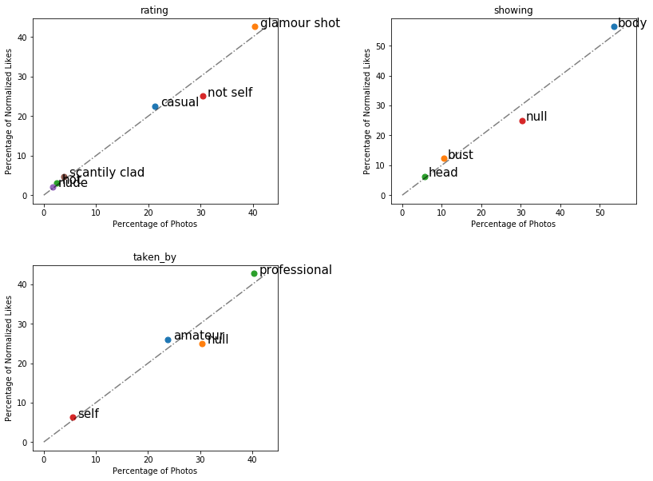

```python
def plot_likes_vs_qty(df, features):
    fig, ax = plt.subplots(2, 2, figsize = (12, 9))
    ax = ax.reshape(-1)
    for i in range(len(features)): # same idea as before
        feature = features[i] # go through all labels in all features
        label_qty = []
        label_likes = []
        labels = np.sort(df[feature].unique())
        for j in range(len(labels)):
            label_qty.append(len(df[df[feature] == labels[j]])/len(df)*100) # calculate % of label in feature
            label_likes.append(df[df[feature] == labels[j]]['likes'].sum()/df['likes'].sum()*100)
            ax[i].scatter(label_qty[j], label_likes[j], s=50) # ^ calculate % of label likes in feature
            ax[i].annotate(labels[j], (label_qty[j]+1, label_likes[j]), fontsize=15)
        ax[i].plot([0, max([max(label_qty), max(label_likes)])], [0, max([max(label_qty), max(label_likes)])], color='k', ls='-.', alpha=0.5)
        ax[i].set_title(feature) # ^ plot axis of symmetry
        ax[i].set_xlabel('Percentage of Photos')
        ax[i].set_ylabel('Percentage of Normalized Likes')
    ax[-1].axis('off')
    plt.tight_layout(pad=3)

plot_likes_vs_qty(data0, features)
```

### So why does it seem like hot pics get all the attention?

On Teddy's Instagram stories she complained that her modeling photos weren't getting any love. It's unlikely this belief came out of nowhere, so let's try to see if there's some other factor at play that makes the contrast more stark.

Glamour shots of the body by professionals are not a surprising majority since she's a model and obviously has thousands of these photos. One thing we've yet to check is how these categories are posted over time. Here we see that glamour and casual photos are being posted far less often than they were in 2015 when they made up over 70% of her content. Meanwhile photos not of herself (eg. still lifes, screenshots, non-portait photography, etc.) have become a staple of her current feed. There is a small uptick in scantily clad, hot, and nude pictures. We also see that on a yearly basis, she's posting less in general.

```
not self photos are on the rise while casual images are being posted less
null photos are on the rise while body images are being posted less
null photos are on the rise while amateur images are being posted less
```

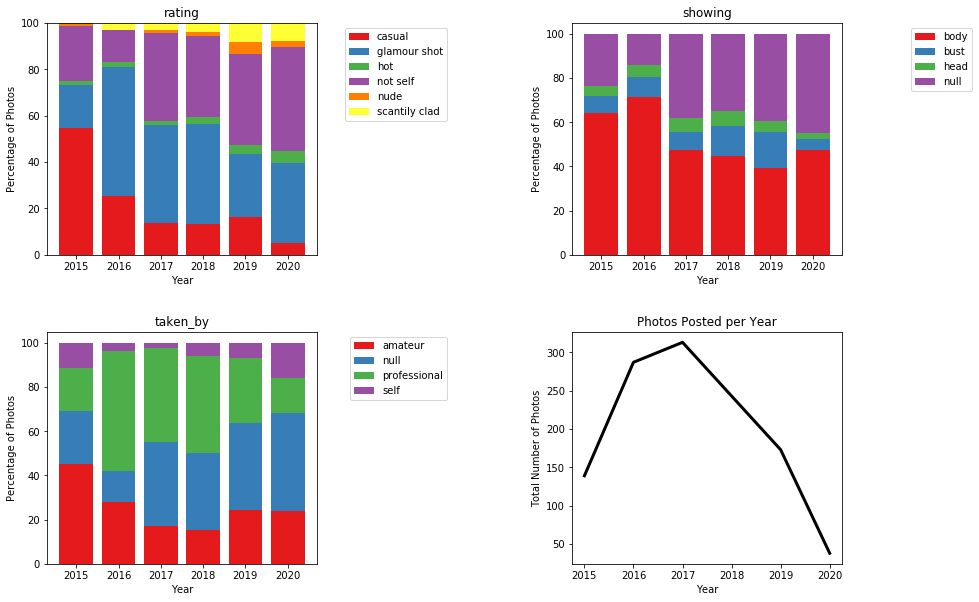

```python
def plot_labels_in_time(df, features):
    fig, ax = plt.subplots(2, 2, figsize = (15, 9)) # you know the drill
    ax = ax.reshape(-1)
    cmap = 'Set2'
    plt.rcParams['image.cmap'] = cmap
    plt.rcParams['axes.prop_cycle'] = plt.cycler(color=eval(f'plt.cm.{cmap}.colors'))
    for i in range(len(features)):
        feature = features[i]
        years = np.sort(data['year'].unique()) # get all the years
        labels = list(np.sort(data[feature].unique())) # get all the labels
        label_base = np.zeros(len(years)) # get label base value for stacked bar
        label_adders = np.zeros(len(years)) # iniatize array to sum label base heights
        label_trend = [] # let's also track the trend of each label
        for j in labels:
            label_y = []
            for k in range(len(years)):
                subset = df.loc[(df['year'] == years[k]) & (df[feature] == j)] # get df of label in a given year
                label_y.append(len(subset)/len(df.loc[(df['year'] == years[k])])*100) # only unhash one line at a time
#                 label_y.append(len(subset)) # unhash to change plot to number of photos
#                 label_y.append(subset['likes'].sum()) # unhash to change plot to sum of normalized likes (will look nearly identical)
                label_adders[k] = label_y[-1] # old height = new base
            ax[i].bar(years, label_y, bottom=label_base)
            label_trend.append(linregress(years, label_y)[0]) # linregress to get trend line of label
            label_base += label_adders
        print(f'{labels[np.argmax(label_trend)]} photos are on the rise while {labels[np.argmin(label_trend)]} images are being posted less')
        ax[i].set_xlabel('Year')
        ax[i].set_ylabel('Percentage of Photos')

        ax[i].set_title(feature)
        ax[i].legend(labels, bbox_to_anchor=[1.5, 0, 0, 1])

    total = []
    for i in years: # use 4th plot to see total posts per year
        total.append(len(df.loc[data['year'] == i])) # get y array for total photos
    ax[-1].plot(years, total, color='k', linewidth=3, alpha=1)
    ax[-1].set_title('Photos Posted per Year')
    ax[-1].set_xlabel('Year')
    ax[-1].set_ylabel('Total Number of Photos')
    plt.tight_layout(pad=3)

plot_labels_in_time(data0, features)
```

### Don't post memes if you're a model

What's actually happening is that content amount and type are being mixed to produce a larger contrast in likes. Teddy historically posted around 50% modeling pics. Whether it be on a runway or for a magazine these photos received many likes. Over time she not only started posting less, but also posting more sexualized photos and random photos not of herself. The hot pics generated slightly more likes than modeling photos or even casual shots. The non portrait images rarely garnered the same amount of likes as a selfie.

In essence, posting a lot of really hot bathroom selfies side by side with a lot of non person images generates a more striking difference in the number of likes from one photo to the next. Without as many glamour and casual photos in the mix the gradient between few likes and many likes on a photo disappears.

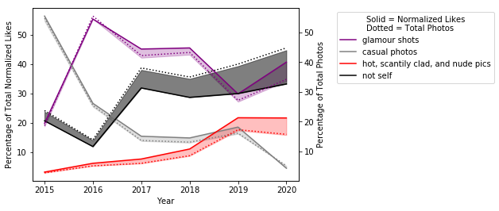

```python
fig, ax = plt.subplots()
years = np.sort(data0['year'].unique())
glam_likes, casual_likes, hot_likes, not_self_likes = [], [], [], []
glam_total, casual_total, hot_total, not_self_total = [], [], [], []
for i in years:
    glam_likes.append(data0.loc[(data0['year'] == i) & (data0['rating'] == 'glamour shot')]['likes'].sum()/data0.loc[data0['year'] == i]['likes'].sum()*100)
    casual_likes.append(data0.loc[(data0['year'] == i) & (data0['rating'] == 'casual')]['likes'].sum()/data0.loc[data0['year'] == i]['likes'].sum()*100)
    hot_likes.append(data0.loc[(data0['year'] == i) & (data0['rating'].isin(['hot', 'scantily clad', 'nude']))]['likes'].sum()/data0.loc[data0['year'] == i]['likes'].sum()*100)
    not_self_likes.append(data0.loc[(data0['year'] == i) & (data0['rating'] == 'not self')]['likes'].sum()/data0.loc[data0['year'] == i]['likes'].sum()*100)

    glam_total.append(len(data0.loc[(data0['year'] == i) & (data0['rating'] == 'glamour shot')])/len(data0.loc[data0['year'] == i])*100)
    casual_total.append(len(data0.loc[(data0['year'] == i) & (data0['rating'] == 'casual')])/len(data0.loc[data0['year'] == i])*100)
    hot_total.append(len(data0.loc[(data0['year'] == i) & (data0['rating'].isin(['hot', 'scantily clad', 'nude']))])/len(data0.loc[data0['year'] == i])*100)
    not_self_total.append(len(data0.loc[(data0['year'] == i) & (data0['rating'] == 'not self')])/len(data0.loc[data0['year'] == i])*100)


ax.plot(years, glam_likes, color='purple')
ax.plot(years, casual_likes, color='grey')
ax.plot(years, hot_likes, color='red')
ax.plot(years, not_self_likes, color='black')
ax.fill_between(years, glam_likes, glam_total, color='purple', alpha=0.25)
ax.fill_between(years, casual_likes, casual_total, color='grey', alpha=0.25)
ax.fill_between(years, hot_likes, hot_total, color='red', alpha=0.25)
ax.fill_between(years, not_self_likes, not_self_total, color='black', alpha=0.5)
ax0 = ax.twinx()
ax0.plot(years, glam_total, color='purple', ls=':')
ax0.plot(years, casual_total, color='grey', ls=':')
ax0.plot(years, hot_total, color='red', ls=':')
ax0.plot(years, not_self_total, color='black', ls=':')

ax.set_xlabel('Year')
ax.set_ylabel('Percentage of Total Normalized Likes')
ax0.set_ylabel('Percentage of Total Photos')
ax.legend(['glamour shots', 'casual photos', 'hot, scantily clad, and nude pics', 'not self'], title='Solid = Normalized Likes\nDotted = Total Photos', bbox_to_anchor=[1.75, 0, 0, 1]);
```

### The 🔥HOTTEST🔥 pic

```python
top_img = data.loc[(data['rating'] == 'nude') & (data['showing'] == 'bust') & (data['taken_by'] == 'self')]
display(top_img)
plot_img(875)
```

|  | photo_num | timestamp | likes | comments | caption | location | rating | showing | taken_by | datetime | date | year | day | hour |
| --- | --- | --- | --- | --- | --- | --- | --- | --- | --- | --- | --- | --- | --- | --- |
| 88 | 1104 | 1568841126 | 10552 | 185 | That Thotty girl from Euphoria Dick Sucking ma... | Los Angeles, California | nude | bust | self | 2019-09-18 21:12:06 | 2019-09-18 | 2019 | 2 | 21 |
| 317 | 875 | 1531264385 | 5606 | 81 | Well-behaved women seldom make history | New York, New York | nude | bust | self | 2018-07-10 23:13:05 | 2018-07-10 | 2018 | 1 | 23 |
| 1110 | 82 | 1444949583 | 126 | 3 | Water nymph looks autumn/winter 2015 💧🐚 #Londo... | London, United Kingdom | nude | bust | self | 2015-10-15 22:53:03 | 2015-10-15 | 2015 | 3 | 22 |

[output not shown]

```python
time_diff = top_img['timestamp'].diff()[top_img.index[1]] # had to run this cell twice to get rid of a warning
print(f'{round(abs(time_diff)/60/60/24/365, 1)} years apart') # hence why it goes from 23 -> 25
top_img_norm = data0.loc[data0.index.isin(top_img.index)]
top_img.loc[:, 'normalized likes'] = top_img_norm.loc[:, 'likes']
display(top_img.loc[:, ['photo_num', 'likes', 'normalized likes', 'date']].head(2))
```

[output not shown]

## Conclusion

Teddy, it's not that we don't want to see your professional shoots, it's that you're not posting them. And if you were to do so, having a couple photos getting 8k likes in between one getting 5k and another getting 10k then the contrast won't seem so steep.

I was really hoping to find something more interesting as I had already schemed up the name TeddyQ Correlation. Perhaps that metric is better suited to describing how much effort I put into getting in the DMs.

## Appendix

### Examples of Photo Labels

#### casual, head, self

This casual selfie with a friend only includes her head.

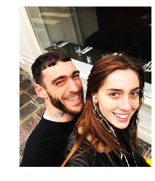

```python
plot_img(477)
```

#### glamour shot, body, professional

The fashion brand name across the photo makes it obvious that this photo has been staged and was shot by a professional. We can see Teddy's entire body here.

[figure not shown]

```python
plot_img(893)
```

#### glamour shot, body, amateur

Here Teddy is clearly wearing a couture ensemble and her whole body is visible. However, this photo is not on a set and likely shot by a friend.

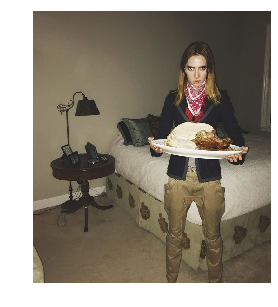

```python
plot_img(410)
```

#### hot, bust, amateur

Between the makeup, jewely, and spaghetti strap top I think it's safe to say she didn't roll out of bed like this. The image is framed from slightly below the shoulders and up and most likely not taken by a professional.

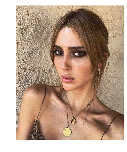

```python
plot_img(1079)
```

#### scantily clad, body, amateur

In this photo there is no guesswork. Just read the caption:

"Ok so last night I was invited to this **messy lingerie themed** Halloween party, and of course I'm so down because I'm basically a hooker and an attention whore so this party was right up my ally. I didn't end up having any fun cuz they make you sign an NDA at the door and it was a pussy fest (there were only girls there). Not only that, but I'm so used to being the only tall hot slut at parties, and this particular party was filled with so many hot girls who had way better bodies than me, so I didn't even stand out or feel special, I was just 1 in 1000 sexy hot slutty girls. I tried to take this picture in the bathroom to discreetly capture my glam and I would like to **thank the real MVP [@giselleadorabrune](https://www.instagram.com/giselleadorabrune/) for Kneeling in a pile of toilette paper to take this picture** of me. Halloween parties are a overrated scam, next year I'm going as a ghost."

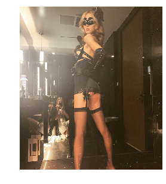

```python
plot_img(1125)
```

#### nude, bust, amateur

This is about as naked as you can get on Instagram.

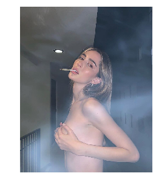

```python
plot_img(1137)
```

#### not self, null, null

For this post Teddy used a meme for the image.

[figure not shown]

```python
plot_img(1150)
```

### All the permutations

These photos show all the possible labels in each catgory, but don't even begin to capture all the possible permutations between rating, showing, and taken by.

### Refreshiging the Data

Naturally I didn't do this whole analysis in a day, so as new photos were posted it was essential to keep the numbers and records up to date. The code below is a modified version of the collection code in section 1.1.4 that reads what the last photo collected on my desktop was and updates from there. It also recollects all of the meta data as the likes and comments on past photos may have changed.

```python
api = InstagramAPI('username', 'password')
```

```python
api.login()
```

```python
# api.getUserFeed('1904001441')
```

```python
# user_data = api.getTotalUserFeed('1904001441') # use this if they have more than 12 new posts
user_data = api.LastJson['items'] # otherwise this is much faster
print(len(user_data))
```

[output not shown]

```python
columns = ['photo_num', 'timestamp', 'likes', 'comments', 'caption', 'location', 'rating', 'showing', 'taken_by']
ar = np.zeros((len(user_data), len(columns)))
df = pd.DataFrame(ar, columns=columns)
for i in range(len(user_data) - 1, -1, -1):
#     if(user_data[i]['taken_at'] == data.loc[data['timestamp'].idxmax(), 'timestamp']):
    if(user_data[i]['taken_at'] == data.loc[data['timestamp'].idxmax(), 'timestamp']):
        counter = 0
        for j in range(i - 1, -1, -1):
            try:
                time = user_data[j]['taken_at']
            except:
                time = ''
            try:
                likes = user_data[j]['like_count']
            except:
                likes = 0
            try:
                comments = user_data[j]['comment_count'] # comments may be disabled
            except:
                comments = 0
            try:
                caption = user_data[j]['caption']['text']
            except:
                caption = ''
            try:
                location = user_data[j]['location']['name'] # location wasn't always a feature
            except:
                location = ''

            df.loc[j, :] = [0, time, likes, comments, caption, location, '', '', '']

            try:
                link = user_data[j]['image_versions2']['candidates'][0]['url']
                urllib.request.urlretrieve(link, f'/Users/XXI/Desktop/TQ_Data/TQ_{len(data) + counter}.jpg')
            except:
                try:
                    link = user_data[j]['carousel_media'][1]['image_versions2']['candidates'][0]['url']
                    urllib.request.urlretrieve(link, f'/Users/XXI/Desktop/TQ_Data/TQ_{len(data) + counter}.jpg')
                except:
                    pass
            counter += 1

df = df.loc[df['timestamp'] != 0]
df['photo_num'] = np.arange(len(data) + len(df) - 1, len(data) - 1, -1)
display(df)
df = pd.concat([data, df], sort=False)
df.sort_values(by='timestamp', inplace=True)
# df.to_csv('/Users/XXI/Desktop/TQ_Data/TQ_Data.csv', index=False)
```